# Simulation

### Libraries

```r
library(dplyr)
library(mosaic)
library(reshape2)
library(readr)
library(gridExtra)
library(GGally)
```

### Simulation

```r
std = c(6,9,10,11,13,5,17,16,12,4,1,18,2,14,8,15,3,7)
set.seed(1)
n = 10000
cols = c("dimIPart1", "dimEPart1", "dimSPart1", "intIPart1", "intEPart1",
                    "intSPart1", "difPart1", "intPart1", "dimPart1", "diPart1", "disPart1",
                    "VQ1", "VQ2", "dimPercPart1", "intPercPart1", "aiPercPart1",
                    "dimIPart2", "dimEPart2", "dimSPart2", "intIPart2", 'intEPart2',
                    "intSPart2", "difPart2", "intPart2", "dimPart2", "diPart2", "disPart2",
                    "SQ1", "SQ2", "dimPercPart2", "intPercPart2", "aiPercPart2",
                    "BQr1", "BQr2", "BQa1", "BQa2", "CQ1", "CQ2", "rho1", "rho2", 'difPart1difPart2')
output = data.frame(dimIPart1 = 1, dimEPart1 = 1, dimSPart1 = 1, intIPart1 = 1, intEPart1 = 1,
                    intSPart1 = 1, difPart1 = 1, intPart1 = 1, dimPart1 = 1, diPart1 = 1, disPart1 = 1,
                    VQ1 = 1, VQ2 = 1, dimPercPart1 = 1, intPercPart1 = 1, aiPercPart1 = 1,
                    dimIPart2 = 1, dimEPart2 = 1, dimSPart2 = 1, intIPart2 = 1, intEPart2 = 1,
                    intSPart2 = 1, difPart2 = 1, intPart2 = 1, dimPart2 = 1, diPart2 = 1, disPart2 = 1,
                    SQ1 = 1, SQ2 = 1, dimPercPart2 = 1, intPercPart2 = 1, aiPercPart2 = 1,
                    BQr1 = 1, BQr2 = 1, BQa1 = 1, BQa2 = 1, CQ1 = 1, CQ2 = 1, rho1 = 1, rho2 = 1,
                    difPart1difPart2 = 1)
output= output[-1,]
for (i in 1:n) {
  jack1 = sample(18,18)
  jack2 = sample(18,18)
  # Step 2
  step2Part1 = abs(jack1 - std)

  # Step 3
  step3Part1 = rep(NA, 18)
  for (i in 1:18) {
    if (step2Part1[i] >= 2) {
      step3Part1[i] = step2Part1[i] - 2
    } else if (step2Part1[i] == 1 || step2Part1[i] == 0) {
      step3Part1[i] = 0
    }
  }

  # Step 4
  dimIPart1 = sum(step2Part1[c(6,10:12,14,16)])
  dimEPart1 = sum(step2Part1[c(1,4,5,7,13,15)])
  dimSPart1 = sum(step2Part1[c(2,3,8,9,17,18)])

  # Step 5
  intIPart1 = sum(step3Part1[c(6,10:12,14,16)])
  intEPart1 = sum(step3Part1[c(1,4,5,7,13,15)])
  intSPart1 = sum(step3Part1[c(2,3,8,9,17,18)])

  # Step 6
  difPart1 = dimIPart1 + dimEPart1 + dimSPart1

  # Step 7
  intPart1 = intIPart1 + intEPart1 + intSPart1

  # Step 8
  dimPart1 = 0
  dimPart1 = dimPart1 + max(dimIPart1,dimEPart1,dimSPart1) - dimIPart1
  dimPart1 = dimPart1 + max(dimIPart1,dimEPart1,dimSPart1) - dimEPart1
  dimPart1 = dimPart1 + max(dimIPart1,dimEPart1,dimSPart1) - dimSPart1

  # Step 9
  diPart1 = 0
  diPart1 = diPart1 + max(intIPart1,intEPart1,intSPart1) - intIPart1
  diPart1 = diPart1 + max(intIPart1,intEPart1,intSPart1) - intEPart1
  diPart1 = diPart1 + max(intIPart1,intEPart1,intSPart1) - intSPart1

  # Step 10
  disPart1 = 0
  for (i in 1:18) {
    if (floor(std[i]/10) != floor(jack1[i]/10)) {
      disPart1 = disPart1 + 1
    }
  }

  # Step 11
  VQ1 = difPart1 + dimPart1 + intPart1 + disPart1

  # Step 12
  VQ2 = dimPart1 + intPart1 + disPart1

  # Step 13
  dimPercPart1 = round((dimPart1 * 100) / difPart1)

  # Step 14
  intPercPart1 = round((intPart1 * 100) / difPart1)

  # Step 15 & 16
  step15Part1 = rep(NA, 18)
  for (i in 1:18) {
    if (floor(jack1[i]/10) == 1 && floor(std[i]/10) == 1) {
      if (jack1[i] > std[i]) {
        step15Part1[i] = "+"
      } else {
        step15Part1[i] = "-"
      }
    } else if (floor(jack1[i]/10) == 0 && floor(std[i]/10) == 0) {
      if (jack1[i] < std[i]) {
        step15Part1[i] = "+"
      } else {
        step15Part1[i] = "-"
      }
    } else {
      step15Part1[i] = "-"
    }
  }

  # Step 17
  positiveSumPart1 = 0
  for (i in 1:18) {
    if (step15Part1[i] == "+") {
      positiveSumPart1 = positiveSumPart1 + step2Part1[i]
    }
  }


  # Step 18
  negativeSumPart1 = 0
  for (i in 1:18) {
    if (step15Part1[i] == "-") {
      negativeSumPart1 = negativeSumPart1 + step2Part1[i]
    }
  }

  # Step 19
  aiPercPart1 = round(negativeSumPart1 * 100 / (positiveSumPart1 + negativeSumPart1))

  # Step 19.5: repeat for part 2
  # Step 2
  step2Part2 = abs(jack2 - std)

  # Step 3
  step3Part2 = rep(NA, 18)
  for (i in 1:18) {
    if (step2Part2[i] >= 2) {
      step3Part2[i] = step2Part2[i] - 2
    } else if (step2Part2[i] == 1 || step2Part2[i] == 0) {
      step3Part2[i] = 0
    }
  }

  # Step 4
  dimIPart2 = sum(step2Part2[c(6,10:12,14,16)])
  dimEPart2 = sum(step2Part2[c(1,4,5,7,13,15)])
  dimSPart2 = sum(step2Part2[c(2,3,8,9,17,18)])

  # Step 5
  intIPart2 = sum(step3Part2[c(6,10:12,14,16)])
  intEPart2 = sum(step3Part2[c(1,4,5,7,13,15)])
  intSPart2 = sum(step3Part2[c(2,3,8,9,17,18)])

  # Step 6
  difPart2 = dimIPart2 + dimEPart2 + dimSPart2

  # Step 7
  intPart2 = intIPart2 + intEPart2 + intSPart2

  # Step 8
  dimPart2 = 0
  dimPart2 = dimPart2 + max(dimIPart2,dimEPart2,dimSPart2) - dimIPart2
  dimPart2 = dimPart2 + max(dimIPart2,dimEPart2,dimSPart2) - dimEPart2
  dimPart2 = dimPart2 + max(dimIPart2,dimEPart2,dimSPart2) - dimSPart2

  # Step 9
  diPart2 = 0
  diPart2 = diPart2 + max(intIPart2,intEPart2,intSPart2) - intIPart2
  diPart2 = diPart2 + max(intIPart2,intEPart2,intSPart2) - intEPart2
  diPart2 = diPart2 + max(intIPart2,intEPart2,intSPart2) - intSPart2

  # Step 10
  disPart2 = 0
  for (i in 1:18) {
    if (floor(std[i]/10) != floor(jack2[i]/10)) {
      disPart2 = disPart2 + 1
    }
  }

  # Step 11
  SQ1 = difPart2 + dimPart2 + intPart2 + disPart2

  # Step 12
  SQ2 = dimPart2 + intPart2 + disPart2

  # Step 13
  dimPercPart2 = round((dimPart2 * 100) / difPart2)

  # Step 14
  intPercPart2 = round((intPart2 * 100) / difPart2)

  # Step 15 & 16
  step15Part2 = rep(NA, 18)
  for (i in 1:18) {
    if (floor(jack2[i]/10) == 1 && floor(std[i]/10) == 1) {
      if (jack2[i] > std[i]) {
        step15Part2[i] = "+"
      } else {
        step15Part2[i] = "-"
      }
    } else if (floor(jack2[i]/10) == 0 && floor(std[i]/10) == 0) {
      if (jack2[i] < std[i]) {
        step15Part2[i] = "+"
      } else {
        step15Part2[i] = "-"
      }
    } else {
      step15Part2[i] = "-"
    }
  }

  # Step 17
  positiveSumPart2 = 0
  for (i in 1:18) {
    if (step15Part2[i] == "+") {
      positiveSumPart2 = positiveSumPart2 + step2Part2[i]
    }
  }


  # Step 18
  negativeSumPart2 = 0
  for (i in 1:18) {
    if (step15Part2[i] == "-") {
      negativeSumPart2 = negativeSumPart2 + step2Part2[i]
    }
  }

  # Step 19
  aiPercPart2 = round(negativeSumPart2 * 100 / (positiveSumPart2 + negativeSumPart2))

  # Step 20 & 21
  BQr1 = round(SQ1/VQ1, digits = 1)
  BQa1 = ceiling(mean(c(SQ1,VQ1)))

  # Step 22 & 23
  BQr2 = round(SQ2/VQ2, digits = 1)
  BQa2 = ceiling(mean(c(SQ2,VQ2)))

  # Step 24 & 25
  if (BQr1 < 1) {
    CQ1 = round((2-BQr1) * BQa1)
  } else {
    CQ1 = round(BQr1 * BQa1)
  }
  if (BQr2 < 1) {
    CQ2 = round((2-BQr2) * BQa2)
  } else {
    CQ2 = round(BQr2 * BQa2)
  }

  # Step 26
  rho1 = (1000 - sum(step2Part1^2))/1000
  rho2 = (1000 - sum(step2Part2^2))/1000

  # Step 27
  difPart1difPart2 = difPart1/difPart2

  # Bind a new row
  vector = c(dimIPart1, dimEPart1, dimSPart1, intIPart1, intEPart1,
                    intSPart1, difPart1, intPart1, dimPart1, diPart1, disPart1,
                    VQ1, VQ2, dimPercPart1, intPercPart1, aiPercPart1,
                    dimIPart2, dimEPart2, dimSPart2, intIPart2, intEPart2,
                    intSPart2, difPart2, intPart2, dimPart2, diPart2, disPart2,
                    SQ1, SQ2, dimPercPart2, intPercPart2, aiPercPart2,
                    BQr1, BQr2, BQa1, BQa2, CQ1, CQ2, rho1, rho2, difPart1difPart2)
  output = rbind(vector, output)
}
output = `colnames<-`(output, cols)
```

### EDA

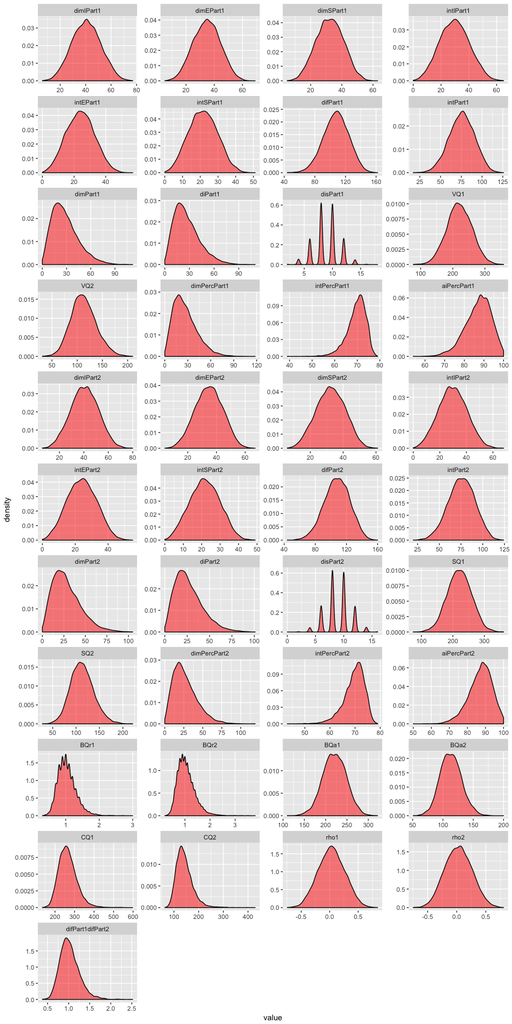

```r
outputmelt = melt(output)
ggplot(outputmelt,aes(x = value)) +
    facet_wrap(~variable,scales = "free", ncol = 4) +
    geom_density(fill = "red", alpha = 0.5)
```

### Exploration of baked in correlation

Correlation between part 1 scores

```r
corpart1 = cor(output[,c(1:16, 39)])
#corpart1
corpart1High = ifelse(abs(corpart1) <= 0.98, NA, corpart1)
#corpart1High
corpart1Low = ifelse(abs(corpart1) >= 0.2, NA, corpart1)
#corpart1Low
```

Correlation between part 2 scores

```r
corpart2 = cor(output[,c(17:32, 40)])
corpart2 = ifelse(corpart2 <= 0.5, NA, corpart2)
#corpart2
corpart2High = ifelse(corpart2 <= 0.98, NA, corpart1)
#corpart2High
```

```r
cor = cor(output)
cor = ifelse(abs(cor) >= .8, cor, NA)
options(max.print =10000)
#print(cor)
```

### Questions

1. Are rho1 and rho2 correlated?

### Answers

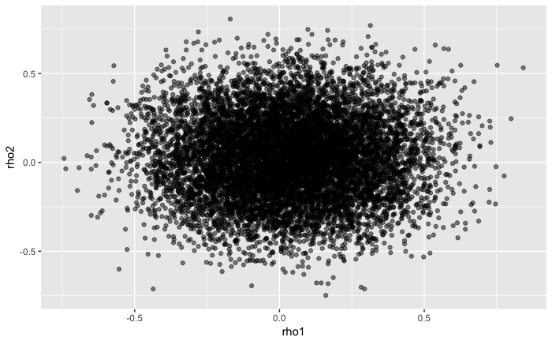

```r
ggplot(output, aes(rho1, rho2)) + geom_point(alpha = 0.5)
```

```r
cor(output$rho1, output$rho2)
```

```
[1] 0.007537454
```

Rho1 and Rho2 are not correlated in the null model, as we’d expect

We expect the first three outcomes since int and dif are both based on the distance of answers to the standard given by hartman.

We also expect the dif and the int to be correlated since they are the addition of the distances in the 3 parts described above. Since the above parts are correlated, we expect the sum of the three parts to also be highly correlated.

We also expec the di and dim scores to be correlated since they are based on subtracting each dim from the highest dim (for dim), and int from the highest int (for di). Thus correlations between dim and int scores will give us correlation between dim and di scores.